# Predicting Colon Cancer Metastasis with a Logstical Regression Model

Alistair Quinn

### Initial Questions

Can we predict which colon cancer patients will become metastatic, based on initial demographic information and clinical features of the cancer?

### Overview and Motivation

Metastatic cancer (spread of the tumour to other parts of the body) is associated with a much higher morbidity (death rate) than non-metastatic cancer.

It is valuable to predict early which patients are likely to be metastatic, so we can target more-aggressive chemotherapy and prevent disease progression, while sparing lower-risk patients the side-effects of highly toxic chemotherapy and radiotherapy.

In addition, performing full-body scans to exclude metastasis is very expensive, and the radiation involved can even increase a patient’s risk of subsequent cancer. Thus we want to minimise unnecessary and potentially harmful investigations and treatments through effective risk stratification.

The aim of this project was to create a simple multivariate model to predict metastasis from basic predictors, such as age, tumour behaviour and grade.

### Data

As discussed earlier, the SEER dataset combines cancer registries covering approximately 34.6% of the US population, collecting data on demographics, tumour site, tumour morphology, stage and grade at diagnosis, treatment and follow-up. We reduced the initial dataset to patients with colon cancer between 2005 and 2015.

### Related Work

#### Prior Research - Computer Algorithms to Predict Life-threatening Medical Conditions

My contribution to this project was inspired by our class lectures and discussion on Machine Learning. It was also informed by my work as Adjunct Researcher at the Centre for Pattern Recognition and Data Analytics (PRaDA) at Deakin University in Victoria, Australia, with my principle investigator, Prof. Svetha Venkatesh.

The work of her team includes a landmark study which involved creating a machine learning algorithm that predicted risk of subsequent suicide after discharge, among patients who presented to the Emergency Department with suicide attempts. The model used demographic data and billing codes, was implemented in the Victorian healthcare system in Geelong, and exceeded prediction accuracy of clinicians. Accurately identifying high-risk patients can allow us to allocate limited resources (eg. admission to hospital) in the most beneficial way possible.

The strategy of using statistical methods to predict escalation in severity of patient outcomes has been applied to predicting the development of acute kidney injury among hospital in-patients (Google’s DeepMind), as well as many other studies at a range of universities predicting escalation of infections (such as urinary tract infection or chest infection) to life-threatening sepsis, or predicting mortality from cancer.

#### Clinical Relevance

In addition informing resource allocation treatment approaches, prediction algorithms can assist doctors in clinical diagnosis. The process of clinical medical diagnosis involves identifying the correct disease causing a patient’s symoptoms, but it also involves correcting identifying ‘red flags’, ie. signs and symptoms that could herald life-threatening conditions.

For example a child with fever, headache and mild cough / sneeze etc. will usually have a benign viral infection, but rarely may have a life-threatening case of bacterial meningitis. Correctly identifying these rare cases is exceptionally difficult to clinicians. Failing to diagnose them leads to tragic consequences, and overly defensive treatment can be expensive, traumatic to patients and can have their own risks. For example, analysing samples of cerebro-spinal fluid taking from the spine with needle in lumbar puncture can help clinicians to exclude meningitis, but the procedure is risky, distressing and painful.

#### Bayesian reasoning in medicine

In the era of evidence-based medicine, clinicians are focused on utilising rational approaches to diagnosis and management. ONe way that these algorithms can be utilised in clinical practice is in Bayesian reasoning. For example, a clinician may have a ‘prior probability’ of a certain life-threatening diagnosis, and subsequent tests (including computer algorithm prediction outcomes), can help him/her update on these priors towards a more informed ‘posterior probability’.

### Importing Data

```r
options(digits=3)
set.seed(1)
library(tidyverse)
library(dslabs)
ds_theme_set()

colon_cancer <- read.csv("colon_cancer.csv", stringsAsFactors = FALSE)
head(colon_cancer)
```

```
##   YEAR_DX STATE POPULATION       ID  REG MARITAL SEX AGE BIRTH SEQ MONTH GRADE
## 1    2005    AK     666946 32410073 1529       2   1  76  1928   2     7     2
## 2    2005    AK     666946 32411240 1529       1   1  44  1961   0     6     9
## 3    2005    AK     666946 32410219 1529       1   1  66  1939   1    11     2
## 4    2005    AK     666946 32410369 1529       2   1  55  1949   0     8     2
## 5    2005    AK     666946 32411279 1529       2   1  76  1929   1    12     1
## 6    2005    AK     666946 32410332 1529       2   2  55  1949   0     6     2
##   REPORTING NODES_POS NODES_EX SIZE T_CLASS N_CLASS M_CLASS STAGE2 AGE_CAT
## 1         1         0       28   40      10       0       0      1      16
## 2         1        98        0  999       5       0       0      0       9
## 3         1         0       10   80      40       0       0      7      14
## 4         1         0        2  999      10       0       0      1      12
## 5         1         0        4   54      30       0       0      1      16
## 6         1         0        5  999      10       0       0      1      12
##   BEHAVIOR HISTOLOGY RACE ETHNIC STAGE STATE_CITY DEATH DEATH_CA DEATH_OTHER
## 1        3         5    3      0     1       2900     0        9           9
## 2        2         5    3      0     0       2900     1        0           0
## 3        3         5    3      0     4       2900     0        1           0
## 4        3         5    3      0     1       2900     1        0           0
## 5        3         5    3      0     1       2900     0        0           1
## 6        3         5    3      0     1       2900     1        0           0
##   SURVIVAL INSURANCE COUNT STATE_Factor
## 1       35        NA     3           AK
## 2      138        NA     1           AK
## 3       41        NA     2           AK
## 4      136        NA     1           AK
## 5        4        NA     2           AK
## 6      138        NA     1           AK
```

```r
names(colon_cancer)
```

```
##  [1] "YEAR_DX"      "STATE"        "POPULATION"   "ID"           "REG"
##  [6] "MARITAL"      "SEX"          "AGE"          "BIRTH"        "SEQ"
## [11] "MONTH"        "GRADE"        "REPORTING"    "NODES_POS"    "NODES_EX"
## [16] "SIZE"         "T_CLASS"      "N_CLASS"      "M_CLASS"      "STAGE2"
## [21] "AGE_CAT"      "BEHAVIOR"     "HISTOLOGY"    "RACE"         "ETHNIC"
## [26] "STAGE"        "STATE_CITY"   "DEATH"        "DEATH_CA"     "DEATH_OTHER"
## [31] "SURVIVAL"     "INSURANCE"    "COUNT"        "STATE_Factor"
```

As shown above, our dataframe now has 357,223 patients, and has 34 columns of variables (including demographic and clinical information).

First we will create a new column of the dataframe for metastasis status (M_CLASS_BINARY), and assign a value of 0 for patients that are not metastatic, and a value of 1 for those who are.

M_CLASS is a set of categories referring to the extent of metastasis (or lack thereof). Please refer to our Cancer 2 Dataset Dictionary for further information.

Thus we will filter out all NAs or MX values - codes 99 and 88. Keep M0 as no metastasis - code 00. Group all subcategories of metastasis together - M1, M1a, M1b, M1c, M1 NOS - codes 10,11,12,13,19. And assign them to 0 and 1 in M_CLASS_BINARY respectively.

```r
data <- colon_cancer %>%
  filter(colon_cancer$M_CLASS < 88) %>%
  mutate(M_CLASS_BINARY = ifelse(M_CLASS == "0", 0, 1))

names(data)
```

```
##  [1] "YEAR_DX"        "STATE"          "POPULATION"     "ID"
##  [5] "REG"            "MARITAL"        "SEX"            "AGE"
##  [9] "BIRTH"          "SEQ"            "MONTH"          "GRADE"
## [13] "REPORTING"      "NODES_POS"      "NODES_EX"       "SIZE"
## [17] "T_CLASS"        "N_CLASS"        "M_CLASS"        "STAGE2"
## [21] "AGE_CAT"        "BEHAVIOR"       "HISTOLOGY"      "RACE"
## [25] "ETHNIC"         "STAGE"          "STATE_CITY"     "DEATH"
## [29] "DEATH_CA"       "DEATH_OTHER"    "SURVIVAL"       "INSURANCE"
## [33] "COUNT"          "STATE_Factor"   "M_CLASS_BINARY"
```

We will use three categories of features to predict the metastasis status - age categories, grades and cancer behaviour. I chose these three parameters as I feel they are clinically relevant parameters we would expect to be associated with metastasis (higher parameters for each being correlated with higher likelihood of metastasis). They are also all able to be assessed on the initial biopsy and consulation.

AGE is the patient’s age at time of diagnosis. BEHAVIOUR is a categorisation of cancer behaviour at time of diagnosis, ranging from from benign to malignant. GRADE is a measure of tumour cell appearance - ie. whether the cancer appears to be aggressive based on appearance of its cells under the microscope.

First we will filter out the NAs for each category.

To remove NAs we filter by the following parameters: AGE_CAT <99 (unknown age) BEHAVIOUR <4 (all colon cancers in this timeframe should be coded as 0-3 and levels 4-6 are related to idiosyncrasies in combining earlier datasets). Note that when filtering here, the dataset did not decrease in size GRADE <5 (1-4 are assocated with Grades 1 to IV, and above this represent NAs or refer to other types of cancer - eg. lymphoma and leukaemia)

```r
new_data <- data %>%
  filter(data$AGE_CAT < 99 & data$BEHAVIOR <4 & data$GRADE < 5)

head(new_data)
```

```
##   YEAR_DX STATE POPULATION       ID  REG MARITAL SEX AGE BIRTH SEQ MONTH GRADE
## 1    2005    AK     666946 32410073 1529       2   1  76  1928   2     7     2
## 2    2005    AK     666946 32410219 1529       1   1  66  1939   1    11     2
## 3    2005    AK     666946 32410369 1529       2   1  55  1949   0     8     2
## 4    2005    AK     666946 32411279 1529       2   1  76  1929   1    12     1
## 5    2005    AK     666946 32410332 1529       2   2  55  1949   0     6     2
## 6    2005    AK     666946 32410213 1529       1   2  51  1953   0     2     1
##   REPORTING NODES_POS NODES_EX SIZE T_CLASS N_CLASS M_CLASS STAGE2 AGE_CAT
## 1         1         0       28   40      10       0       0      1      16
## 2         1         0       10   80      40       0       0      7      14
## 3         1         0        2  999      10       0       0      1      12
## 4         1         0        4   54      30       0       0      1      16
## 5         1         0        5  999      10       0       0      1      12
## 6         1         0        5  999       5       0       0      0      11
##   BEHAVIOR HISTOLOGY RACE ETHNIC STAGE STATE_CITY DEATH DEATH_CA DEATH_OTHER
## 1        3         5    3      0     1       2900     0        9           9
## 2        3         5    3      0     4       2900     0        1           0
## 3        3         5    3      0     1       2900     1        0           0
## 4        3         5    3      0     1       2900     0        0           1
## 5        3         5    3      0     1       2900     1        0           0
## 6        2         5    3      0     0       2900     1        0           0
##   SURVIVAL INSURANCE COUNT STATE_Factor M_CLASS_BINARY
## 1       35        NA     3           AK              0
## 2       41        NA     2           AK              0
## 3      136        NA     1           AK              0
## 4        4        NA     2           AK              0
## 5      138        NA     1           AK              0
## 6      142        NA     1           AK              0
```

We have filtered the dataframe from 328610 datapoints to 274659, and are now able to perform a ‘complete case analysis’.

Now we will measure the prevalence of metastasis in our dataset, because this has implications for the machine learning approach we deploy (unbalanced datasets may introduce bias and inaccurate results for either level of the binary variable we are classifying).

```r
prevalence <- sum(new_data$M_CLASS_BINARY == "1") / length(new_data$M_CLASS_BINARY)
prevalence
```

```
## [1] 0.171
```

```r
new_data$AGE[which.min(new_data$AGE)]
```

```
## [1] 6
```

```r
new_data$AGE[which.max(new_data$AGE)]
```

```
## [1] 110
```

The age at diagnosis of colon cancer in the dataset ranges from 6 years (sadly) to 110 years.

Now we will visualise the counts of age at time of first diagnosis across all colon cancers.

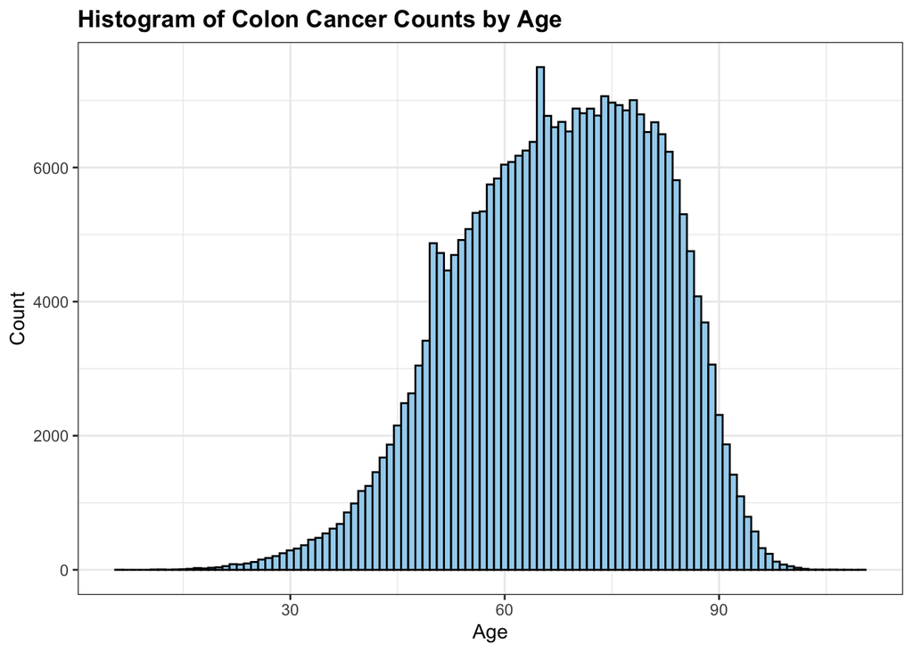

```r
ages <- ggplot(new_data, aes(x=AGE)) +
  geom_histogram(binwidth = 1, color = "black", fill = "lightskyblue2") +
  labs(title="Histogram of Colon Cancer Counts by Age") +
  labs(x="Age", y="Count")

ages
```

The age distribution is left-skewed, with some outlier counts, likely representing random variation.

Let’s compare the distribution of colon cancer cases with metastasis against those without, using a smoothed density plot (stratified by metastasis status).

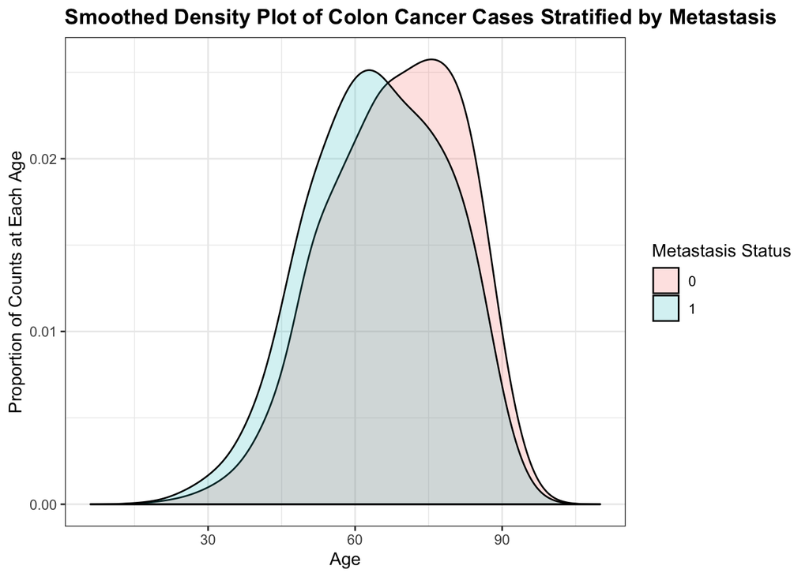

```r
new_data %>% ggplot(aes(x=AGE, fill=as.factor(M_CLASS_BINARY))) +
  geom_density(alpha = 0.2, bw = 3) +
  labs(title="Smoothed Density Plot of Colon Cancer Cases Stratified by Metastasis") +
  labs(x="Age", y="Proportion of Counts at Each Age") +
  scale_fill_discrete(name = "Metastasis Status")
```

Next, let’s show a two-way table comparing tumour behaviour categories against metastasis status.

```r
table(new_data$BEHAVIOR, new_data$M_CLASS_BINARY)
```

```
##
##          0      1
##   2   2979      0
##   3 224746  46934
```

```r
prop.table(table(new_data$BEHAVIOR, new_data$M_CLASS_BINARY), margin=2)
```

```
##
##          0      1
##   2 0.0131 0.0000
##   3 0.9869 1.0000
```

Columns are 0 and 1 (for no metastasis and metastasis respectively).

The rows can range from 0 to 3, but note that all patients in the dataset were either 2 (in situ), or 3 (malignant), with all metastatic patients malignant. This is as we would expect, because patients who are metastatic are more likely to have more malignant (aggressive) disease.

```r
table(new_data$GRADE, new_data$M_CLASS_BINARY)
```

```
##
##          0      1
##   1  25194   2656
##   2 161479  29422
##   3  36042  13148
##   4   5010   1708
```

```r
prop.table(table(new_data$GRADE, new_data$M_CLASS_BINARY), margin=2)
```

```
##
##          0      1
##   1 0.1106 0.0566
##   2 0.7091 0.6269
##   3 0.1583 0.2801
##   4 0.0220 0.0364
```

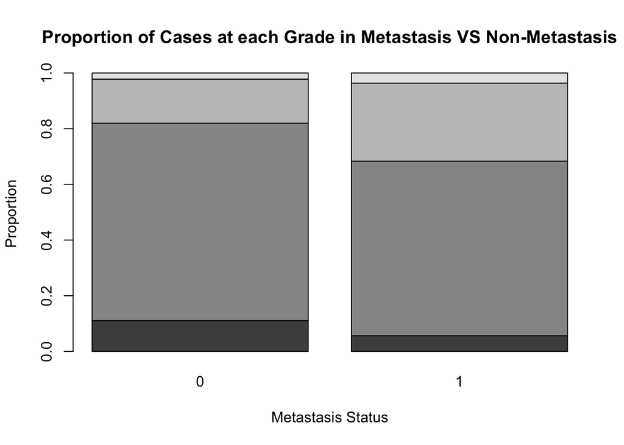

```r
# install.packages("RColorBrewer")
# library(RColorBrewer)

barplot(prop.table(table(new_data$GRADE, new_data$M_CLASS_BINARY), margin=2),
        main = "Proportion of Cases at each Grade in Metastasis VS Non-Metastasis",
        xlab = "Metastasis Status",
        ylab = "Proportion",)
```

Darker shades of grey at the bottom of the graph correspond to lower cancer grades (1,2,3,4). The plot shows that non-metastatic cases (0) have a higher proportion of lower grades (1 and 2) compared to the metastatic cases (1). This difference should make grade an appropriate feature to predict metastasis.

Now we will split the data into even training and test sets.

```r
library(caret)
set.seed(1)
train_index <- createDataPartition(new_data$M_CLASS_BINARY, times = 1, p = 0.5, list = FALSE)
```

Use this index to define training and test sets:

```r
train_set <- new_data[train_index, ]
test_set <- new_data[-train_index, ]

head(train_set)
```

```
##    YEAR_DX STATE POPULATION       ID  REG MARITAL SEX AGE BIRTH SEQ MONTH GRADE
## 1     2005    AK     666946 32410073 1529       2   1  76  1928   2     7     2
## 10    2005    AK     666946 32410138 1529       5   1  78  1927   0     9     2
## 11    2005    AK     666946 32411080 1529       5   2  60  1944   0     1     2
## 12    2005    AK     666946 32409930 1529       4   1  55  1949   0     3     2
## 13    2005    AK     666946 32410098 1529       2   2  44  1961   0     9     2
## 14    2005    AK     666946 32411320 1529       2   2  73  1931   1     2     2
##    REPORTING NODES_POS NODES_EX SIZE T_CLASS N_CLASS M_CLASS STAGE2 AGE_CAT
## 1          1         0       28   40      10       0       0      1      16
## 10         1        98        0  999      30       0       0      1      16
## 11         1         2       13   30      20      20       0      3      13
## 12         1         6       18   25      30      20       0      3      12
## 13         1         2        6   40      30      10      10      7       9
## 14         1         0        6   45      30       0       0      1      15
##    BEHAVIOR HISTOLOGY RACE ETHNIC STAGE STATE_CITY DEATH DEATH_CA DEATH_OTHER
## 1         3         5    3      0     1       2900     0        9           9
## 10        3         5    3      0     1       2900     1        0           0
## 11        3         5    3      0     2       2900     0        1           0
## 12        3         5    3      0     2       2900     1        0           0
## 13        3         5    3      0     4       2900     0        1           0
## 14        3         5    3      0     1       2900     0        0           1
##    SURVIVAL INSURANCE COUNT STATE_Factor M_CLASS_BINARY
## 1        35        NA     3           AK              0
## 10      135        NA     1           AK              0
## 11      101        NA     1           AK              0
## 12      141        NA     1           AK              0
## 13       20        NA     1           AK              1
## 14       93        NA     2           AK              0
```

```r
head(test_set)
```

```
##   YEAR_DX STATE POPULATION       ID  REG MARITAL SEX AGE BIRTH SEQ MONTH GRADE
## 2    2005    AK     666946 32410219 1529       1   1  66  1939   1    11     2
## 3    2005    AK     666946 32410369 1529       2   1  55  1949   0     8     2
## 4    2005    AK     666946 32411279 1529       2   1  76  1929   1    12     1
## 5    2005    AK     666946 32410332 1529       2   2  55  1949   0     6     2
## 6    2005    AK     666946 32410213 1529       1   2  51  1953   0     2     1
## 7    2005    AK     666946 32410101 1529       1   2  61  1944   0     8     2
##   REPORTING NODES_POS NODES_EX SIZE T_CLASS N_CLASS M_CLASS STAGE2 AGE_CAT
## 2         1         0       10   80      40       0       0      7      14
## 3         1         0        2  999      10       0       0      1      12
## 4         1         0        4   54      30       0       0      1      16
## 5         1         0        5  999      10       0       0      1      12
## 6         1         0        5  999       5       0       0      0      11
## 7         1         3        8   35      40      10       0      7      13
##   BEHAVIOR HISTOLOGY RACE ETHNIC STAGE STATE_CITY DEATH DEATH_CA DEATH_OTHER
## 2        3         5    3      0     4       2900     0        1           0
## 3        3         5    3      0     1       2900     1        0           0
## 4        3         5    3      0     1       2900     0        0           1
## 5        3         5    3      0     1       2900     1        0           0
## 6        2         5    3      0     0       2900     1        0           0
## 7        3         5    3      0     2       2900     0        0           1
##   SURVIVAL INSURANCE COUNT STATE_Factor M_CLASS_BINARY
## 2       41        NA     2           AK              0
## 3      136        NA     1           AK              0
## 4        4        NA     2           AK              0
## 5      138        NA     1           AK              0
## 6      142        NA     1           AK              0
## 7        5        NA     1           AK              0
```

Note that train_set has 137,330 rows and test_set has 137,329 rows.

```r
prevalence_train <- sum(train_set$M_CLASS_BINARY == "1") / length(train_set$M_CLASS_BINARY)
prevalence_train
```

```
## [1] 0.172
```

```r
prevalence_test <- sum(test_set$M_CLASS_BINARY == "1") / length(test_set$M_CLASS_BINARY)
prevalence_test
```

```
## [1] 0.17
```

Note that the prevalence of metastasis in the training and test sets is similar (about 17%).

Next we will fit the logistic regression model for age, using the function glm (generalized linear model). Because our outcome variable of metastasis is a dichotomous / binary variable (0 or 1), we will specify binomial in the glm function.

```r
glm_fit_age <- glm(M_CLASS_BINARY ~ AGE, data=train_set, family = "binomial")
summary(glm_fit_age)
```

```
##
## Call:
## glm(formula = M_CLASS_BINARY ~ AGE, family = "binomial", data = train_set)
##
## Deviance Residuals:
##    Min      1Q  Median      3Q     Max
## -0.974  -0.642  -0.582  -0.527   2.193
##
## Coefficients:
##              Estimate Std. Error z value Pr(>|z|)
## (Intercept) -0.391962   0.034376   -11.4   <2e-16 ***
## AGE         -0.017771   0.000514   -34.6   <2e-16 ***
## ---
## Signif. codes:  0 '***' 0.001 '**' 0.01 '*' 0.05 '.' 0.1 ' ' 1
##
## (Dispersion parameter for binomial family taken to be 1)
##
##     Null deviance: 125953  on 137329  degrees of freedom
## Residual deviance: 124760  on 137328  degrees of freedom
## AIC: 124764
##
## Number of Fisher Scoring iterations: 4
```

Next we will create generalised linear models for tumour behaviour and grade.

```r
glm_fit_behaviour <- glm(M_CLASS_BINARY ~ BEHAVIOR, data=train_set, family = "binomial")
summary(glm_fit_behaviour)
```

```
##
## Call:
## glm(formula = M_CLASS_BINARY ~ BEHAVIOR, family = "binomial",
##     data = train_set)
##
## Deviance Residuals:
##    Min      1Q  Median      3Q     Max
## -0.617  -0.617  -0.617  -0.617   1.871
##
## Coefficients:
##             Estimate Std. Error z value Pr(>|z|)
## (Intercept)    -43.6      114.2   -0.38     0.70
## BEHAVIOR        14.0       38.1    0.37     0.71
##
## (Dispersion parameter for binomial family taken to be 1)
##
##     Null deviance: 125953  on 137329  degrees of freedom
## Residual deviance: 125399  on 137328  degrees of freedom
## AIC: 125403
##
## Number of Fisher Scoring iterations: 14
```

```r
glm_fit_grade <- glm(M_CLASS_BINARY ~ GRADE, data=train_set, family = "binomial")
summary(glm_fit_grade)
```

```
##
## Call:
## glm(formula = M_CLASS_BINARY ~ GRADE, family = "binomial", data = train_set)
##
## Deviance Residuals:
##    Min      1Q  Median      3Q     Max
## -0.937  -0.585  -0.585  -0.455   2.155
##
## Coefficients:
##             Estimate Std. Error z value Pr(>|z|)
## (Intercept)  -2.7588     0.0268  -102.9   <2e-16 ***
## GRADE         0.5407     0.0115    47.2   <2e-16 ***
## ---
## Signif. codes:  0 '***' 0.001 '**' 0.01 '*' 0.05 '.' 0.1 ' ' 1
##
## (Dispersion parameter for binomial family taken to be 1)
##
##     Null deviance: 125953  on 137329  degrees of freedom
## Residual deviance: 123756  on 137328  degrees of freedom
## AIC: 123760
##
## Number of Fisher Scoring iterations: 4
```

Now we will calculate the confusion matrix, to test the performance of the logistic regression model for age.

```r
p_hat_age <- predict(glm_fit_age, newdata = test_set, type="response")
y_hat_age <- ifelse(p_hat_age > 0.5, 1, 0)
confusionMatrix(data = as.factor(y_hat_age), reference = as.factor(test_set$M_CLASS_BINARY))
```

```
## Confusion Matrix and Statistics
##
##           Reference
## Prediction      0      1
##          0 113975  23354
##          1      0      0
##
##                Accuracy : 0.83
##                  95% CI : (0.828, 0.832)
##     No Information Rate : 0.83
##     P-Value [Acc > NIR] : 0.502
##
##                   Kappa : 0
##
##  Mcnemar's Test P-Value : <2e-16
##
##             Sensitivity : 1.00
##             Specificity : 0.00
##          Pos Pred Value : 0.83
##          Neg Pred Value :  NaN
##              Prevalence : 0.83
##          Detection Rate : 0.83
##    Detection Prevalence : 1.00
##       Balanced Accuracy : 0.50
##
##        'Positive' Class : 0
##
```

As seen above, the first iteration of the model appears to have an accuracy of 0.83, however the sensitivity is 1 and the specificity is 0.

We can adjust the p_hat_age cutoff to be greater than 0.17 to reflect this imbalance between levels of our metastasis outcome.

```r
y_hat_age <- ifelse(p_hat_age > 0.17, 1, 0)
confusionMatrix(data = as.factor(y_hat_age), reference = as.factor(test_set$M_CLASS_BINARY))
```

```
## Confusion Matrix and Statistics
##
##           Reference
## Prediction     0     1
##          0 61602 10195
##          1 52373 13159
##
##                Accuracy : 0.544
##                  95% CI : (0.542, 0.547)
##     No Information Rate : 0.83
##     P-Value [Acc > NIR] : 1
##
##                   Kappa : 0.061
##
##  Mcnemar's Test P-Value : <2e-16
##
##             Sensitivity : 0.540
##             Specificity : 0.563
##          Pos Pred Value : 0.858
##          Neg Pred Value : 0.201
##              Prevalence : 0.830
##          Detection Rate : 0.449
##    Detection Prevalence : 0.523
##       Balanced Accuracy : 0.552
##
##        'Positive' Class : 0
##
```

Now we have an accuracy of 0.545, which is slightly better than a coin-toss. Our sensitivity and specificity are now 0.541 and 0.564, showing that the algorithm is now predicting a reasonable prorpotion of the true positives as positive and true negatives as negative.

Next we will assess our algorithms for tumour behaviour.

```r
p_hat_behaviour <- predict(glm_fit_behaviour, newdata = test_set, type="response")
y_hat_behaviour <- ifelse(p_hat_behaviour > 0.17, 1, 0)
confusionMatrix(data = as.factor(y_hat_behaviour), reference = as.factor(test_set$M_CLASS_BINARY))
```

```
## Confusion Matrix and Statistics
##
##           Reference
## Prediction      0      1
##          0   1517      0
##          1 112458  23354
##
##                Accuracy : 0.181
##                  95% CI : (0.179, 0.183)
##     No Information Rate : 0.83
##     P-Value [Acc > NIR] : 1
##
##                   Kappa : 0.005
##
##  Mcnemar's Test P-Value : <2e-16
##
##             Sensitivity : 0.0133
##             Specificity : 1.0000
##          Pos Pred Value : 1.0000
##          Neg Pred Value : 0.1720
##              Prevalence : 0.8299
##          Detection Rate : 0.0110
##    Detection Prevalence : 0.0110
##       Balanced Accuracy : 0.5067
##
##        'Positive' Class : 0
##
```

Next and assessing the algorithm for tumour grade:

```r
p_hat_grade <- predict(glm_fit_grade, newdata = test_set, type="response")
y_hat_grade <- ifelse(p_hat_grade > 0.17, 1, 0)
confusionMatrix(data = as.factor(y_hat_grade), reference = as.factor(test_set$M_CLASS_BINARY))
```

```
## Confusion Matrix and Statistics
##
##           Reference
## Prediction     0     1
##          0 93476 16002
##          1 20499  7352
##
##                Accuracy : 0.734
##                  95% CI : (0.732, 0.737)
##     No Information Rate : 0.83
##     P-Value [Acc > NIR] : 1
##
##                   Kappa : 0.125
##
##  Mcnemar's Test P-Value : <2e-16
##
##             Sensitivity : 0.820
##             Specificity : 0.315
##          Pos Pred Value : 0.854
##          Neg Pred Value : 0.264
##              Prevalence : 0.830
##          Detection Rate : 0.681
##    Detection Prevalence : 0.797
##       Balanced Accuracy : 0.567
##
##        'Positive' Class : 0
##
```

Next we will create an overall generalised linear model that includes age and grade, but excludes behaviour as it was a poor predictor in isolation.

```r
glm_fit_overall <- glm(M_CLASS_BINARY ~ AGE + GRADE, data=train_set, family = "binomial")
summary(glm_fit_overall)
```

```
##
## Call:
## glm(formula = M_CLASS_BINARY ~ AGE + GRADE, family = "binomial",
##     data = train_set)
##
## Deviance Residuals:
##    Min      1Q  Median      3Q     Max
## -1.327  -0.639  -0.553  -0.477   2.398
##
## Coefficients:
##              Estimate Std. Error z value Pr(>|z|)
## (Intercept) -1.559347   0.042329   -36.8   <2e-16 ***
## AGE         -0.018504   0.000517   -35.8   <2e-16 ***
## GRADE        0.554943   0.011540    48.1   <2e-16 ***
## ---
## Signif. codes:  0 '***' 0.001 '**' 0.01 '*' 0.05 '.' 0.1 ' ' 1
##
## (Dispersion parameter for binomial family taken to be 1)
##
##     Null deviance: 125953  on 137329  degrees of freedom
## Residual deviance: 122476  on 137327  degrees of freedom
## AIC: 122482
##
## Number of Fisher Scoring iterations: 4
```

And assess the confusion matrix:

```r
p_hat_overall <- predict(glm_fit_overall, newdata = test_set, type="response")
y_hat_overall <- ifelse(p_hat_overall > 0.17, 1, 0)
confusionMatrix(data = as.factor(y_hat_overall), reference = as.factor(test_set$M_CLASS_BINARY))
```

```
## Confusion Matrix and Statistics
##
##           Reference
## Prediction     0     1
##          0 67909  9881
##          1 46066 13473
##
##                Accuracy : 0.593
##                  95% CI : (0.59, 0.595)
##     No Information Rate : 0.83
##     P-Value [Acc > NIR] : 1
##
##                   Kappa : 0.107
##
##  Mcnemar's Test P-Value : <2e-16
##
##             Sensitivity : 0.596
##             Specificity : 0.577
##          Pos Pred Value : 0.873
##          Neg Pred Value : 0.226
##              Prevalence : 0.830
##          Detection Rate : 0.494
##    Detection Prevalence : 0.566
##       Balanced Accuracy : 0.586
##
##        'Positive' Class : 0
##
```

The overall algorithm has an accuracy of 59.3%, a sensitivty of 59.6% and a specificity of 57.7%. Thus it is marginally better at prediction than a coin toss.

Next we can reassess our algorithms, using the F1-score (the harmonic mean of precision and recall) instead:

```r
y_hat_age <- ifelse(p_hat_age > 0.17, 1, 0)
F_meas(data = as.factor(y_hat_age), reference = as.factor(test_set$M_CLASS_BINARY))
```

```
## [1] 0.663
```

```r
y_hat_behaviour <- ifelse(p_hat_behaviour > 0.17, 1, 0)
F_meas(data = as.factor(y_hat_behaviour), reference = as.factor(test_set$M_CLASS_BINARY))
```

```
## [1] 0.0263
```

```r
y_hat_grade <- ifelse(p_hat_grade > 0.17, 1, 0)
F_meas(data = as.factor(y_hat_grade), reference = as.factor(test_set$M_CLASS_BINARY))
```

```
## [1] 0.837
```

```r
y_hat_overall <- ifelse(p_hat_overall > 0.17, 1, 0)
F_meas(data = as.factor(y_hat_overall), reference = as.factor(test_set$M_CLASS_BINARY))
```

```
## [1] 0.708
```

With the exclusion of behaviour, the other univariate algorithms had reasonable F1 scores (0.663 and 0.837), and the F1 score for the overall multivariate algorithm (combining age and grade) is 0.708.